# Registration and statistical power on simulated data

The jiku-data survey (`jiku-data-datasets.ipynb`) showed that elastic registration introduces geometric regularity into data that are essentially noise, SRSF registration in particular. This notebook studies that behaviour under controlled conditions using the power1d framework: signal geometry from `power1d.geom`, smooth Gaussian noise from `power1d.noise.SmoothGaussian` (FWHM = 25 % of the domain throughout), and power1d's definition of numerical power.

**Design.** A one-sample experiment on J observations of Q = 101 nodes. The null model is pure noise; the alternative model adds a `GaussianPulse` of amplitude `amp` (in units of the noise standard deviation) and full width at half maximum `fwhm` (% of the domain), centred at 50 % of the domain, with the centre of each observation's pulse displaced by an integer number of nodes drawn from N(0, `qsd`) (`qsd` in nodes, i.e. % of the domain, following power1d's use of `q` for domain position) — the "position variability" of the signal. Parts C and D replace the position shift by a random warp of the signal (`reg1d.random_warp`, three basis functions, strength `wsd`), which is the kind of timing variability elastic methods are designed to remove. Each simulated dataset is registered by each method (or left unregistered), a one-sample t continuum is computed with `power1d.stats.t_1sample`, and its maximum is recorded.

**Power, as defined by power1d.** The critical threshold `zstar` is the (1 − α) quantile of the maximum t statistic under the null model, and power is the probability that the maximum t statistic under the alternative model exceeds `zstar`. Because registration changes the null distribution, `zstar` is computed *per method* from registered null data ("calibrated" thresholds); in addition the false-positive rate of each method at the *unregistered* threshold is reported, which measures how much regularity the method introduces into noise (the price of registering without recalibrating the test).

**Other quantities recorded per simulated dataset**: the residual sum of squares about the mean after registration relative to before (`SSE ratio`); the peak of the cross-sectional mean of the registered data relative to the true amplitude (`peak / amp`, amplitude recovery); and the squared correlation between the true pulse displacements and the displacements estimated by the warps at the pulse centre, γᵢ(0.5) − 0.5 (`timing r²`, timing recovery; undefined when `qsd` = 0).

**Methods.** `none` (linearly registered data as generated), `SRSF lam=0` (unpenalised Fisher–Rao alignment), `SRSF` (`lam='auto'`), `DDTW` (derivative DTW, strict step pattern, smoothed warps), `continuous` (Ramsay–Li, 4 basis functions), `self-modelling` (shape-invariant model, 4 basis functions). Iteration counts are reduced (SRSF 3, others 2) to keep the run time of roughly 2 000 registrations per method manageable; all other settings are the defaults.

**Simulations and their size.** The number of simulated datasets per condition is set by the constants `N_NULL`, `N_ALT`, `N_WARP`, `N_TWO` at the top of the code cell below and is printed again in every results section. Currently: **Part A** (pure noise, J ∈ {5, 10, 20, 50}): N_NULL = 100 datasets per J. **Part B** (signal with position shifts, one factor varied at a time about the base condition J = 10, amp = 1, fwhm = 20, qsd = 5: amp ∈ {0.5, 1, 2, 4}, fwhm ∈ {10, 20, 40}, qsd ∈ {0, 2.5, 5, 10}, J ∈ {5, 10, 20, 50}): N_ALT = 60 datasets per condition. **Part C** (signal with random warps, wsd ∈ {0, 0.05, 0.1, 0.2} at amp = 1 and wsd ∈ {0, 0.1, 0.2} at amp = 2): N_WARP = 30 datasets per condition. **Part D** (two-sample timing difference): N_TWO = 30 datasets per condition. The null simulations of Part A provide the thresholds for Parts B and C; Part D uses its own null (no group difference). Parts C and D are deliberately small and their results are approximate (see the warnings in those sections). With 100 null datasets the 95th percentile of the null distribution, and hence every calibrated power, is itself uncertain by a few percent.

**Re-running and refining.** The results are cached in `power_simulated_datasets_results.pkl`; the notebook loads the cache and runs only conditions that are missing or that hold fewer datasets than requested. To refine, increase the `N_*` constants (in the code cell below and in `make_power_notebook.py`, which holds the same code) or run, e.g. overnight,

```
python make_power_notebook.py --simulate --n-null 400 --n-alt 200 --n-warp 200 --n-two 200
python make_power_notebook.py
```

The full run at the current sizes took about 3 hours on two cores.

```python
import sys, os, time, pickle, warnings
for _v in ('OMP_NUM_THREADS', 'OPENBLAS_NUM_THREADS', 'MKL_NUM_THREADS'):
    os.environ.setdefault(_v, '1')      # one BLAS thread per worker process
sys.path.insert(0, os.path.abspath('../src'))   # so that this notebook finds registration1d without installation
import numpy as np
from matplotlib import pyplot as plt
import registration1d as reg1d
import power1d
warnings.filterwarnings('ignore')

# ----- number of simulated datasets per condition (approximate results: increase and re-run) -----
N_NULL = 100     # Part A: pure noise, per sample size
N_ALT  = 60      # Part B: signal with position shifts, per condition
N_WARP = 30      # Part C: signal with random warps, per condition
N_TWO  = 30      # Part D: two-sample timing difference, per condition

Q, NOISE_FWHM, ALPHA = 101, 25, 0.05
CACHE   = 'power_simulated_datasets_results.pkl'
METHODS = ['none', 'SRSF lam=0', 'SRSF', 'DDTW', 'continuous', 'self-modelling']
COLORS  = dict(zip(METHODS, ['k', 'r', 'orange', 'b', 'g', 'm']))
TGRID   = np.linspace(0, 1, Q)

def make_dataset(J, amp, fwhm, qsd, wsd, delta, rng):
    """Noise (power1d SmoothGaussian) plus, if amp > 0, a GaussianPulse per observation.
    qsd   : SD (nodes) of an integer displacement of the pulse centre (position variability)
    wsd   : sigma of a random warp (reg1d.random_warp, 3 basis functions) applied to the pulse
    delta : a fixed smooth warp t + delta sin(pi t) applied to the pulse (peak displaced by ~delta
            of the domain), used for the group difference of Part D
    Returns (y, shifts, wtrue): shifts in units of the normalised domain, wtrue the (J,Q) warps
    applied to the pulse (identity when wsd == 0)."""
    noise = power1d.noise.SmoothGaussian(J=J, Q=Q, mu=0, sigma=1, fwhm=NOISE_FWHM)
    noise.random()
    y      = noise.value.copy()
    shifts = np.zeros(J)
    wtrue  = np.tile(TGRID, (J, 1))
    if amp > 0:
        dq = np.clip(np.round(rng.normal(0, qsd, J)), -30, 30).astype(int) if qsd > 0 else np.zeros(J, int)
        if wsd > 0:
            wtrue = reg1d.random_warp(J, Q, sigma=wsd, n_basis=3, random_state=int(rng.integers(2**31)))
        wd = TGRID + delta * np.sin(np.pi * TGRID)
        for i in range(J):
            sig = power1d.geom.GaussianPulse(Q=Q, q=int(50 + dq[i]), fwhm=fwhm, amp=amp).value
            if delta != 0:
                sig = reg1d.warp.apply_warp(sig, wd)
            if wsd > 0:
                sig = reg1d.warp.apply_warp(sig, wtrue[i])
            y[i] += sig
        shifts = dq / (Q - 1)
    return y, shifts, wtrue

def register(y, method):
    if method == 'none':
        return y, None
    if method == 'SRSF lam=0':
        r = reg1d.register_srsf(y, lam=0, max_iter=3)
    elif method == 'SRSF':
        r = reg1d.register_srsf(y, max_iter=3)
    elif method == 'DDTW':
        r = reg1d.register_dtw(y, derivative=True, step_pattern='strict', smooth=0.03, max_iter=2)
    elif method == 'continuous':
        r = reg1d.register_continuous(y, n_basis=4, max_iter=2)
    elif method == 'self-modelling':
        r = reg1d.register_sim(y, n_basis=4, max_iter=2)
    return r.y, r

def _r2(a, b):
    """Squared correlation between two flattened arrays (nan if either is constant)."""
    a, b = np.asarray(a, float).ravel(), np.asarray(b, float).ravel()
    if a.std() == 0 or b.std() == 0:
        return np.nan
    return np.corrcoef(a, b)[0, 1]**2

def one_dataset(args):
    """Simulate one dataset and register it with every method; returns per-method metrics.
    two=False: one-sample design (J observations).
    two=True : two-sample design (J observations per group; group B carries the timing
               difference delta); statistics are two-tailed max |t|."""
    J, amp, fwhm, qsd, wsd, delta, two, seed = args
    rng      = np.random.default_rng(seed)
    np.random.seed(seed)          # power1d draws from numpy's global generator
    if two:
        yA, sA, wA = make_dataset(J, amp, fwhm, qsd, wsd, 0.0,   rng)
        yB, sB, wB = make_dataset(J, amp, fwhm, qsd, wsd, delta, rng)
        y, s, wtrue = np.vstack([yA, yB]), np.r_[sA, sB], np.vstack([wA, wB])
    else:
        y, s, wtrue = make_dataset(J, amp, fwhm, qsd, wsd, delta, rng)
    sse0     = ((y - y.mean(axis=0))**2).sum()
    dtrue    = wtrue - TGRID
    out      = {}
    for m in METHODS:
        try:
            yr, r = register(y, m)
        except Exception:
            yr, r = y, None
        d = np.zeros_like(y) if r is None else r.displacement_fields
        if two:
            t   = np.abs(power1d.stats.t_2sample(yr[:J], yr[J:]))
            td  = np.abs(power1d.stats.t_2sample(d[:J], d[J:]))
            td  = np.where(np.isfinite(td), td, 0.0)      # displacement is identically zero at the end points
        else:
            t   = power1d.stats.t_1sample(yr)
            td  = np.zeros(Q)
        est = np.zeros(len(y)) if r is None else r.warps.asarray()[:, (Q - 1) // 2] - 0.5
        if qsd > 0:
            r2 = _r2(s, est)
        elif wsd > 0:
            r2 = _r2(dtrue - dtrue.mean(axis=0), d - d.mean(axis=0))
        else:
            r2 = np.nan
        out[m] = dict(tmax=float(t.max()), tdmax=float(td.max()), t=t.astype(np.float32),
                      sse=float(((yr - yr.mean(axis=0))**2).sum() / sse0),
                      peak=float(yr.mean(axis=0).max()), r2=r2, y=yr.astype(np.float32))
    return out

def simulate(J, amp, fwhm, qsd, wsd, delta, two, n, seed0, workers=2):
    """n datasets of one condition; returns dict method -> dict of stacked metrics (+ 'n')."""
    from multiprocessing import Pool
    args = [(J, amp, fwhm, qsd, wsd, delta, two, seed0 + i)  for i in range(n)]
    t0   = time.time()
    with Pool(workers) as pool:
        res = pool.map(one_dataset, args, chunksize=1)
    out = dict(n=n)
    for m in METHODS:
        out[m] = {k: np.array([r[m][k] for r in res])  for k in ('tmax', 'tdmax', 't', 'sse', 'peak', 'r2')}
        out[m]['y_example'] = res[0][m]['y']
    print(f'J={J:3d} amp={amp:<4g} fwhm={fwhm:<3g} qsd={qsd:<4g} wsd={wsd:<4g} delta={delta:<5g} '
          f'{"two" if two else "one"}-sample  n={n}  ({time.time()-t0:6.0f} s)', flush=True)
    return out

def key(c):  return (c['J'], c['amp'], c['fwhm'], c['qsd'], c['wsd'], c['delta'], c['two'])

BASE  = dict(J=10, amp=1.0, fwhm=20, qsd=5.0, wsd=0.0, delta=0.0, two=False)
NULLS = [dict(BASE, J=J, amp=0.0, qsd=0.0)  for J in (5, 10, 20, 50)]
ALTS  = []
for amp in (0.5, 1.0, 2.0, 4.0):    ALTS.append(dict(BASE, amp=amp))
for fwhm in (10, 40):               ALTS.append(dict(BASE, fwhm=fwhm))
for qsd in (0.0, 2.5, 10.0):        ALTS.append(dict(BASE, qsd=qsd))
for J in (5, 20, 50):               ALTS.append(dict(BASE, J=J))
WARPS = [dict(BASE, qsd=0.0, wsd=wsd)  for wsd in (0.05, 0.1, 0.2)]      # wsd = 0 is the qsd = 0 condition of Part B
WARPS += [dict(BASE, amp=2.0, qsd=0.0, wsd=wsd)  for wsd in (0.0, 0.1, 0.2)] # the same at twice the amplitude
TWOS  = [dict(BASE, amp=2.0, qsd=0.0, wsd=0.1, delta=delta, two=True)  for delta in (0.0, 0.05, 0.1)]

def run_all(n_null=N_NULL, n_alt=N_ALT, n_warp=N_WARP, n_two=N_TWO):
    """Run (or load from the cache) every condition; a cached condition is re-run only when it
    holds fewer datasets than requested, so increasing the N_* constants refines the results."""
    results = {}
    if os.path.exists(CACHE):
        with open(CACHE, 'rb') as f:
            results = pickle.load(f)
    todo = [(c, n_null) for c in NULLS] + [(c, n_alt) for c in ALTS] + [(c, n_warp) for c in WARPS] + [(c, n_two) for c in TWOS]
    for k, (c, n) in enumerate(todo):
        if key(c) in results and results[key(c)]['n'] >= n:
            continue
        results[key(c)] = simulate(n=n, seed0=1000 * k, **c)
        with open(CACHE, 'wb') as f:
            pickle.dump(results, f)
    return results

if __name__ == '__main__' and '--simulate' in sys.argv:
    kw = {}
    for name in ('n_null', 'n_alt', 'n_warp', 'n_two'):
        flag = '--' + name.replace('_', '-')
        if flag in sys.argv:
            kw[name] = int(sys.argv[sys.argv.index(flag) + 1])
    run_all(**kw)
```

```python
results = run_all()          # loads the cached results; runs the simulations (hours) if the cache is absent
print(len(results), 'conditions')
```

```
25 conditions
```

## Part A: pure noise

### What registration does to noise

One simulated null dataset (J = 10) before and after each method. The unregistered curves are smooth Gaussian random fields with no common structure; the registered panels show what each method makes of them.

```
Part A: 100 simulated null datasets per sample size
```

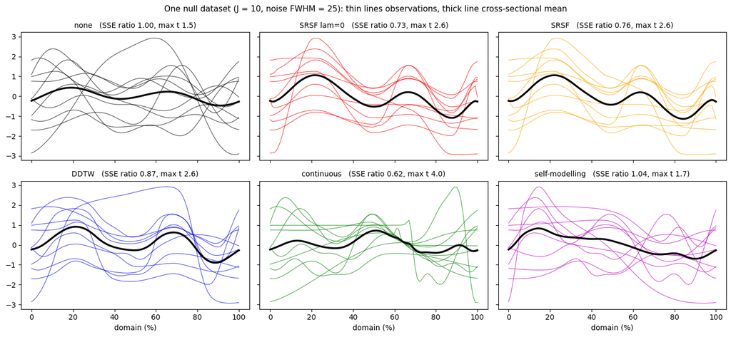

```python
res = results[(10, 0.0, 20, 0.0, 0.0, 0.0, False)]
print(f"Part A: {res['n']} simulated null datasets per sample size")
fig, AX = plt.subplots(2, 3, figsize=(14, 6.5), sharex=True, sharey=True)
t = np.linspace(0, 100, Q)
for ax, m in zip(AX.ravel(), METHODS):
    y = res[m]['y_example']
    ax.plot(t, y.T, color=COLORS[m], lw=0.8, alpha=0.7)
    ax.plot(t, y.mean(axis=0), color='k', lw=2.5)
    ax.set_title(f"{m}   (SSE ratio {res[m]['sse'].mean():.2f}, max t {res[m]['tmax'][0]:.1f})", size=10)
for ax in AX[1]: ax.set_xlabel('domain (%)')
plt.suptitle('One null dataset (J = 10, noise FWHM = 25): thin lines observations, thick line cross-sectional mean', size=11)
plt.tight_layout(); plt.show()
```

### Regularity introduced into noise, as a function of sample size

Left: residual reduction (a descriptive measure of how much the warps "explain"). Middle: the false-positive rate of the one-sample test at the *unregistered* critical threshold — the probability of declaring a significant mean signal in pure noise when the data are registered but the test is not recalibrated (nominal rate α = 0.05, dotted line). Right: the calibrated critical threshold `zstar` for each method, i.e. the threshold the test would need in order to keep α = 0.05 after registration.

```
Part A: null datasets per sample size: {5: 100, 10: 100, 20: 100, 50: 100}
```

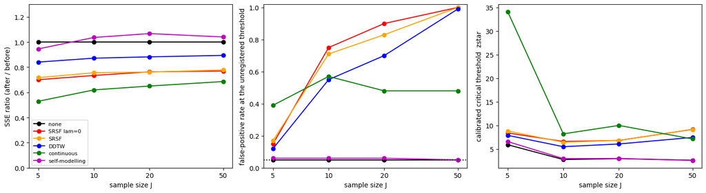

```
  J            none      SRSF lam=0            SRSF            DDTW      continuous  self-modelling
false-positive rate at the unregistered threshold:
  5            0.05            0.15            0.17            0.12            0.39            0.06
 10            0.05            0.75            0.71            0.55            0.57            0.06
 20            0.05            0.90            0.83            0.70            0.48            0.06
 50            0.05            1.00            1.00            0.99            0.48            0.05
calibrated threshold zstar:
  5            5.91            8.41            8.83            7.90           34.12            6.58
 10            2.77            6.60            6.43            5.49            8.22            2.96
 20            2.96            6.82            6.83            6.07           10.00            3.00
 50            2.62            9.16            9.13            7.46            7.14            2.58
```

```python
Js = [5, 10, 20, 50]
print('Part A: null datasets per sample size:', {J: results[(J, 0.0, 20, 0.0, 0.0, 0.0, False)]['n'] for J in Js})
fig, AX = plt.subplots(1, 3, figsize=(15, 4.2))
zstar = {}
for m in METHODS:
    sse, fpr, zs = [], [], []
    for J in Js:
        res  = results[(J, 0.0, 20, 0.0, 0.0, 0.0, False)]
        z0   = np.percentile(results[(J, 0.0, 20, 0.0, 0.0, 0.0, False)]['none']['tmax'], 100 * (1 - ALPHA))
        zs.append(np.percentile(res[m]['tmax'], 100 * (1 - ALPHA)))
        fpr.append((res[m]['tmax'] > z0).mean())
        sse.append(res[m]['sse'].mean())
        zstar[(J, m)] = zs[-1]
    AX[0].plot(Js, sse, 'o-', color=COLORS[m], label=m)
    AX[1].plot(Js, fpr, 'o-', color=COLORS[m], label=m)
    AX[2].plot(Js, zs,  'o-', color=COLORS[m], label=m)
AX[1].axhline(ALPHA, color='k', ls=':')
AX[0].set_ylabel('SSE ratio (after / before)');            AX[0].set_ylim(0, 1.3)
AX[1].set_ylabel('false-positive rate at the unregistered threshold'); AX[1].set_ylim(0, 1.02)
AX[2].set_ylabel('calibrated critical threshold  zstar')
for ax in AX:
    ax.set_xscale('log'); ax.set_xticks(Js); ax.set_xticklabels(Js); ax.minorticks_off(); ax.set_xlabel('sample size J')
AX[0].legend(fontsize=8)
plt.tight_layout(); plt.show()
print(f"{'J':>3s} " + ' '.join(f'{m:>15s}' for m in METHODS))
print('false-positive rate at the unregistered threshold:')
for J in Js:
    z0 = np.percentile(results[(J, 0.0, 20, 0.0, 0.0, 0.0, False)]['none']['tmax'], 100 * (1 - ALPHA))
    print(f'{J:3d} ' + ' '.join(f"{(results[(J, 0.0, 20, 0.0, 0.0, 0.0, False)][m]['tmax'] > z0).mean():15.2f}" for m in METHODS))
print('calibrated threshold zstar:')
for J in Js:
    print(f'{J:3d} ' + ' '.join(f'{zstar[(J, m)]:15.2f}' for m in METHODS))
```

### The distribution of the maximum t statistic under the null

The whole null distribution, not only its 95th percentile: the unregistered maximum t statistic (black) against the registered ones, for J = 10 and J = 50.

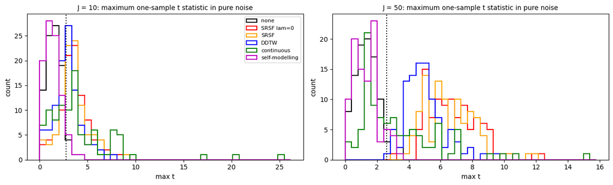

```python
fig, AX = plt.subplots(1, 2, figsize=(13, 4))
for ax, J in zip(AX, (10, 50)):
    res  = results[(J, 0.0, 20, 0.0, 0.0, 0.0, False)]
    bins = np.linspace(0, max(res[m]['tmax'].max() for m in METHODS) * 1.05, 40)
    for m in METHODS:
        ax.hist(res[m]['tmax'], bins=bins, histtype='step', color=COLORS[m], lw=1.5, label=m)
    ax.axvline(np.percentile(res['none']['tmax'], 95), color='k', ls=':')
    ax.set_title(f'J = {J}: maximum one-sample t statistic in pure noise', size=10)
    ax.set_xlabel('max t'); ax.set_ylabel('count')
AX[0].legend(fontsize=8)
plt.tight_layout(); plt.show()
```

### Mean t continua of registered noise

Registration that aligns noise extrema across observations concentrates the spurious effect where the aligned extrema land. The average t continuum over the null datasets shows whether the introduced regularity has a preferred location (it should be flat, near zero, for unregistered noise).

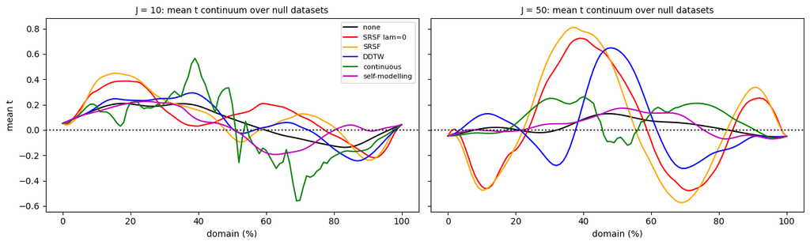

```python
fig, AX = plt.subplots(1, 2, figsize=(13, 4), sharey=True)
for ax, J in zip(AX, (10, 50)):
    res = results[(J, 0.0, 20, 0.0, 0.0, 0.0, False)]
    for m in METHODS:
        ax.plot(t, res[m]['t'].mean(axis=0), color=COLORS[m], label=m)
    ax.axhline(0, color='k', ls=':'); ax.set_title(f'J = {J}: mean t continuum over null datasets', size=10)
    ax.set_xlabel('domain (%)')
AX[0].set_ylabel('mean t'); AX[0].legend(fontsize=8)
plt.tight_layout(); plt.show()
```

## Part B: signal plus noise

### The base condition

```
Part B: 60 simulated datasets per condition
```

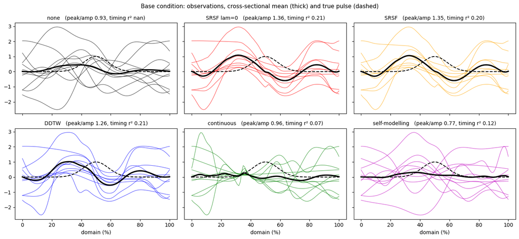

```python
res = results[key(BASE)]
print(f"Part B: {res['n']} simulated datasets per condition")
sig = power1d.geom.GaussianPulse(Q=Q, q=50, fwhm=BASE['fwhm'], amp=BASE['amp']).value
fig, AX = plt.subplots(2, 3, figsize=(14, 6.5), sharex=True, sharey=True)
for ax, m in zip(AX.ravel(), METHODS):
    y = res[m]['y_example']
    ax.plot(t, y.T, color=COLORS[m], lw=0.8, alpha=0.7)
    ax.plot(t, y.mean(axis=0), color='k', lw=2.5)
    ax.plot(t, sig, 'k--', lw=1.5)
    ax.set_title(f"{m}   (peak/amp {res[m]['peak'].mean():.2f}, timing r² {np.nanmean(res[m]['r2']):.2f})", size=10)
for ax in AX[1]: ax.set_xlabel('domain (%)')
plt.suptitle('Base condition: observations, cross-sectional mean (thick) and true pulse (dashed)', size=11)
plt.tight_layout(); plt.show()
```

### Power, amplitude recovery and timing recovery

Each row varies one factor about the base condition. Left: calibrated power (the threshold of each method comes from its own registered null distribution at the same J). Middle: the peak of the cross-sectional mean relative to the true amplitude (1 = the amplitude is recovered; below 1 = smeared by position variability or noise; above 1 = inflated by aligned noise). Right: squared correlation between true and estimated pulse displacements (how much of the imposed timing variability the warps recover; blank where qsd = 0). The number of simulated datasets per condition is printed above the figure.

```
Part B: datasets per condition: [60]
```

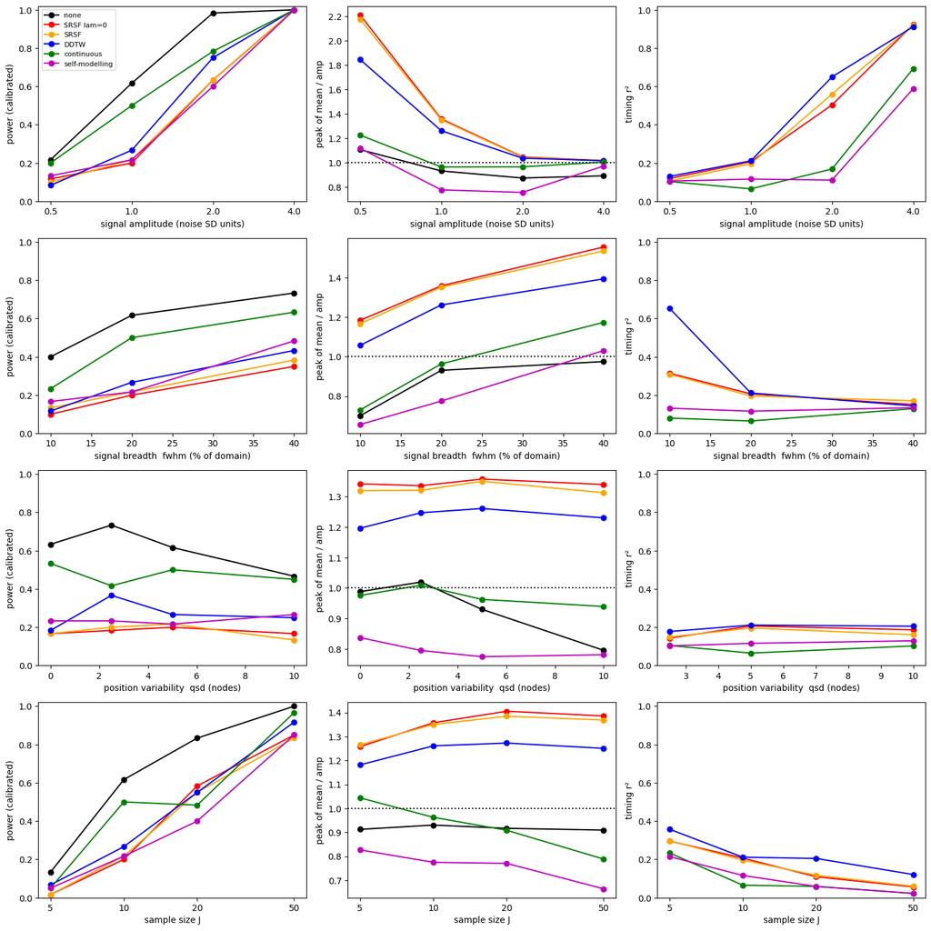

```
calibrated power
                   condition            none      SRSF lam=0            SRSF            DDTW      continuous  self-modelling
                     amp=0.5            0.22            0.12            0.10            0.08            0.20            0.13
                     amp=1.0            0.62            0.20            0.22            0.27            0.50            0.22
                     amp=2.0            0.98            0.63            0.63            0.75            0.78            0.60
                     amp=4.0            1.00            1.00            1.00            1.00            1.00            1.00
                     fwhm=10            0.40            0.10            0.13            0.12            0.23            0.17
                     fwhm=20            0.62            0.20            0.22            0.27            0.50            0.22
                     fwhm=40            0.73            0.35            0.38            0.43            0.63            0.48
                     qsd=0.0            0.63            0.17            0.17            0.18            0.53            0.23
                     qsd=2.5            0.73            0.18            0.20            0.37            0.42            0.23
                     qsd=5.0            0.62            0.20            0.22            0.27            0.50            0.22
                    qsd=10.0            0.47            0.17            0.13            0.25            0.45            0.27
                         J=5            0.13            0.02            0.02            0.07            0.05            0.05
                        J=10            0.62            0.20            0.22            0.27            0.50            0.22
                        J=20            0.83            0.58            0.55            0.55            0.48            0.40
                        J=50            1.00            0.85            0.83            0.92            0.97            0.85
```

```python
def power(c, m):
    z = zstar[(c['J'], m)]
    return (results[key(c)][m]['tmax'] > z).mean()

sweeps = [('amp',  [0.5, 1.0, 2.0, 4.0], 'signal amplitude (noise SD units)'),
          ('fwhm', [10, 20, 40],          'signal breadth  fwhm (% of domain)'),
          ('qsd',  [0.0, 2.5, 5.0, 10.0], 'position variability  qsd (nodes)'),
          ('J',    [5, 10, 20, 50],       'sample size J')]
print('Part B: datasets per condition:', sorted({results[key(dict(BASE, **{n: v}))]['n'] for n, vv, _ in sweeps for v in vv}))
fig, AX = plt.subplots(4, 3, figsize=(15, 15))
for row, (name, values, label) in zip(AX, sweeps):
    for m in METHODS:
        conds = [dict(BASE, **{name: v}) for v in values]
        row[0].plot(values, [power(c, m) for c in conds], 'o-', color=COLORS[m], label=m)
        row[1].plot(values, [results[key(c)][m]['peak'].mean() / c['amp'] for c in conds], 'o-', color=COLORS[m])
        row[2].plot(values, [np.nanmean(results[key(c)][m]['r2']) for c in conds], 'o-', color=COLORS[m])
    row[0].set_ylabel('power (calibrated)'); row[0].set_ylim(0, 1.02)
    row[1].set_ylabel('peak of mean / amp');  row[1].axhline(1, color='k', ls=':')
    row[2].set_ylabel('timing r²');           row[2].set_ylim(0, 1.02)
    for ax in row:
        ax.set_xlabel(label)
        if name in ('J', 'amp'):
            ax.set_xscale('log'); ax.set_xticks(values); ax.set_xticklabels(values); ax.minorticks_off()
AX[0, 0].legend(fontsize=8)
plt.tight_layout(); plt.show()

print('calibrated power')
print(f"{'condition':>28s} " + ' '.join(f'{m:>15s}' for m in METHODS))
for name, values, _ in sweeps:
    for v in values:
        c = dict(BASE, **{name: v})
        print(f"{name+'='+str(v):>28s} " + ' '.join(f'{power(c, m):15.2f}' for m in METHODS))
```

### Power at the unregistered threshold

The same power curves when the test is *not* recalibrated after registration (the threshold of the unregistered data is used for every method). This is what a naive pipeline — register, then test as usual — would report, and it must be read together with the false-positive rates of Part A: a method whose false-positive rate is 0.5 will show high "power" here for any signal, including none.

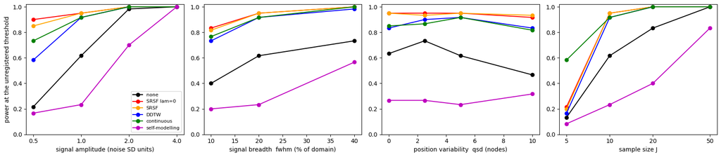

```python
fig, AX = plt.subplots(1, 4, figsize=(17, 3.8))
for ax, (name, values, label) in zip(AX, sweeps):
    for m in METHODS:
        conds = [dict(BASE, **{name: v}) for v in values]
        p = [(results[key(c)][m]['tmax'] > zstar[(c['J'], 'none')]).mean() for c in conds]
        ax.plot(values, p, 'o-', color=COLORS[m], label=m)
    ax.set_xlabel(label); ax.set_ylim(0, 1.02)
    if name in ('J', 'amp'):
        ax.set_xscale('log'); ax.set_xticks(values); ax.set_xticklabels(values); ax.minorticks_off()
AX[0].set_ylabel('power at the unregistered threshold'); AX[0].legend(fontsize=8)
plt.tight_layout(); plt.show()
```

### Mean t continua with the signal present

Where the evidence for the signal sits after registration, for the amplitude sweep (J = 10, fwhm = 20, qsd = 5). The dotted horizontal line is the unregistered threshold; the coloured dotted lines are each method's calibrated threshold.

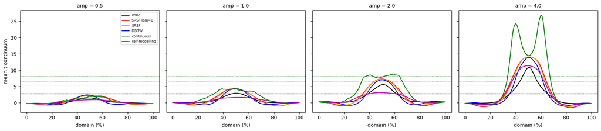

```python
fig, AX = plt.subplots(1, 4, figsize=(17, 3.8), sharey=True)
for ax, amp in zip(AX, (0.5, 1.0, 2.0, 4.0)):
    c = dict(BASE, amp=amp)
    for m in METHODS:
        ax.plot(t, results[key(c)][m]['t'].mean(axis=0), color=COLORS[m], label=m)
        ax.axhline(zstar[(c['J'], m)], color=COLORS[m], ls=':', lw=0.8)
    ax.set_title(f'amp = {amp}', size=10); ax.set_xlabel('domain (%)')
AX[0].set_ylabel('mean t continuum'); AX[0].legend(fontsize=7)
plt.tight_layout(); plt.show()
```

## Part C: signal plus random warp

Position shifts are a crude form of timing variability. Here the base pulse (J = 10, amp = 1, fwhm = 20, no position shift) is deformed by a random warp per observation (`reg1d.random_warp`, three basis functions, strength `wsd`; wsd = 0.1 displaces the pulse centre by about 4.5 nodes SD, comparable to qsd = 5 of Part B, but also stretches and compresses the pulse). This is the timing variability that elastic methods are built to remove. The quantities are those of Part B; timing recovery is now the squared correlation between the true and estimated displacement *fields* (after removing the per-node mean across observations, since the estimated warps are centred).

The sweep is run at the base amplitude (amp = 1, top row) and at twice the noise SD (amp = 2, bottom row), where the warps have a signal to work on.

**Warning: approximate results.** N_WARP datasets per condition (printed below), so power and the recovery measures carry a sampling uncertainty of roughly ±0.1; the section is intended to point in a direction, not to fix values. The wsd = 0 point at amp = 1 is the qsd = 0 condition of Part B.

```
Part C, amp = 1.0: datasets per condition: [60, 30, 30, 30] (wsd = [0.0, 0.05, 0.1, 0.2] )
Part C, amp = 2.0: datasets per condition: [30, 30, 30] (wsd = [0.0, 0.1, 0.2] )
```

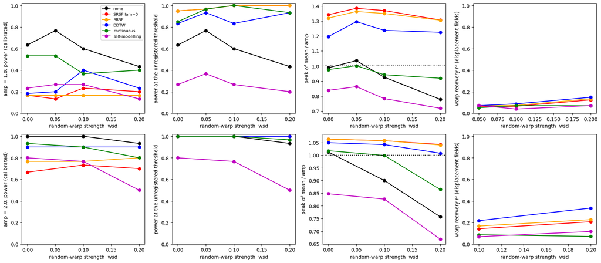

```
 amp    wsd            none      SRSF lam=0            SRSF            DDTW      continuous  self-modelling
   1      0            0.63            0.17            0.17            0.18            0.53            0.23   (calibrated power)
   1   0.05            0.77            0.13            0.17            0.20            0.53            0.27   (calibrated power)
   1    0.1            0.60            0.23            0.17            0.40            0.37            0.27   (calibrated power)
   1    0.2            0.43            0.20            0.17            0.23            0.40            0.13   (calibrated power)
   2      0            1.00            0.67            0.77            0.90            0.93            0.80   (calibrated power)
   2    0.1            1.00            0.73            0.77            0.90            0.90            0.77   (calibrated power)
   2    0.2            0.93            0.70            0.80            0.90            0.80            0.50   (calibrated power)
```

```python
fig, AX = plt.subplots(2, 4, figsize=(17, 7.5))
for row, amp, wsds in zip(AX, (1.0, 2.0), ([0.0, 0.05, 0.1, 0.2], [0.0, 0.1, 0.2])):
    conds = [dict(BASE, amp=amp, qsd=0.0, wsd=w) for w in wsds]
    print(f'Part C, amp = {amp}: datasets per condition:', [results[key(c)]['n'] for c in conds], '(wsd =', wsds, ')')
    for m in METHODS:
        row[0].plot(wsds, [power(c, m) for c in conds], 'o-', color=COLORS[m], label=m)
        row[1].plot(wsds, [(results[key(c)][m]['tmax'] > zstar[(c['J'], 'none')]).mean() for c in conds], 'o-', color=COLORS[m])
        row[2].plot(wsds, [results[key(c)][m]['peak'].mean() / c['amp'] for c in conds], 'o-', color=COLORS[m])
        row[3].plot(wsds, [np.nanmean(results[key(c)][m]['r2']) for c in conds], 'o-', color=COLORS[m])
    row[0].set_ylabel(f'amp = {amp}: power (calibrated)');   row[0].set_ylim(0, 1.02)
    row[1].set_ylabel('power at the unregistered threshold'); row[1].set_ylim(0, 1.02)
    row[2].set_ylabel('peak of mean / amp');                 row[2].axhline(1, color='k', ls=':')
    row[3].set_ylabel('warp recovery r² (displacement fields)'); row[3].set_ylim(0, 1.02)
    for ax in row: ax.set_xlabel('random-warp strength  wsd')
AX[0, 0].legend(fontsize=8)
plt.tight_layout(); plt.show()
print(f"{'amp':>4s} {'wsd':>6s} " + ' '.join(f'{m:>15s}' for m in METHODS))
for amp, wsds in ((1.0, [0.0, 0.05, 0.1, 0.2]), (2.0, [0.0, 0.1, 0.2])):
    for c in [dict(BASE, amp=amp, qsd=0.0, wsd=w) for w in wsds]:
        print(f"{amp:4g} {c['wsd']:6g} " + ' '.join(f'{power(c, m):15.2f}' for m in METHODS) + '   (calibrated power)')
```

One dataset of the strongest random-warp condition (wsd = 0.2) before and after registration; the dashed line is the undeformed pulse.

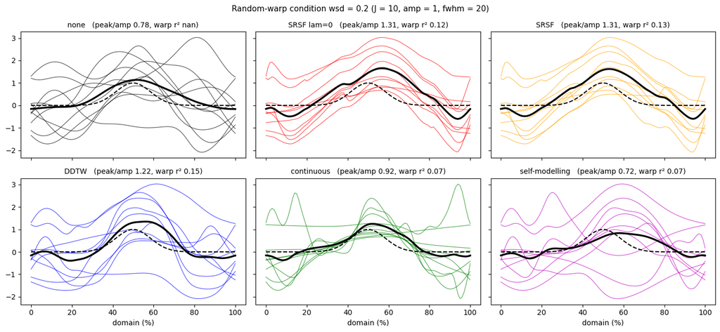

```python
res = results[key(dict(BASE, qsd=0.0, wsd=0.2))]
fig, AX = plt.subplots(2, 3, figsize=(14, 6.5), sharex=True, sharey=True)
for ax, m in zip(AX.ravel(), METHODS):
    y = res[m]['y_example']
    ax.plot(t, y.T, color=COLORS[m], lw=0.8, alpha=0.7)
    ax.plot(t, y.mean(axis=0), color='k', lw=2.5)
    ax.plot(t, sig, 'k--', lw=1.5)
    ax.set_title(f"{m}   (peak/amp {res[m]['peak'].mean():.2f}, warp r² {np.nanmean(res[m]['r2']):.2f})", size=10)
for ax in AX[1]: ax.set_xlabel('domain (%)')
plt.suptitle('Random-warp condition wsd = 0.2 (J = 10, amp = 1, fwhm = 20)', size=11)
plt.tight_layout(); plt.show()
```

## Part D: true timing differences

A two-sample design (J = 10 per group) in which both groups carry the pulse (amp = 2, fwhm = 20) deformed by the random warps of Part C (wsd = 0.1), and group B's pulse is additionally displaced by a fixed smooth warp t + δ sin(πt) — a true timing difference between the groups that moves the peak by about δ of the domain (δ ∈ {0, 0.05, 0.1}; δ = 0 is the null). All 2J observations are registered together to one pooled template, and two two-tailed max |t| statistics are recorded: the two-sample test on the registered amplitudes (which a registration that removes the timing difference should *lose*) and the two-sample test on the displacement fields (which should *gain* it; undefined for `none`). Thresholds are calibrated per method and per test from the δ = 0 datasets.

```
Part D: datasets per condition: [30, 30, 30] (delta = [0.0, 0.05, 0.1] )
```

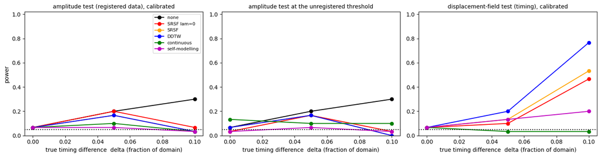

```
 delta            none      SRSF lam=0            SRSF            DDTW      continuous  self-modelling
     0            0.07            0.07            0.07            0.07            0.07            0.07   amplitude test, calibrated
                   nan            0.07            0.07            0.07            0.07            0.07   displacement-field test, calibrated
  0.05            0.20            0.20            0.17            0.17            0.10            0.07   amplitude test, calibrated
                   nan            0.10            0.13            0.20            0.03            0.13   displacement-field test, calibrated
   0.1            0.30            0.07            0.03            0.03            0.03            0.03   amplitude test, calibrated
                   nan            0.47            0.53            0.77            0.03            0.20   displacement-field test, calibrated
calibrated thresholds, amplitude test:    {'none': np.float64(3.03), 'SRSF lam=0': np.float64(2.78), 'SRSF': np.float64(2.86), 'DDTW': np.float64(2.88), 'continuous': np.float64(3.41), 'self-modelling': np.float64(2.55)}
calibrated thresholds, displacement test: {'none': np.float64(0.0), 'SRSF lam=0': np.float64(3.41), 'SRSF': np.float64(3.72), 'DDTW': np.float64(3.27), 'continuous': np.float64(2.55), 'self-modelling': np.float64(2.41)}
```

```python
deltas = [0.0, 0.05, 0.1]
conds  = [dict(BASE, amp=2.0, qsd=0.0, wsd=0.1, delta=d, two=True) for d in deltas]
print('Part D: datasets per condition:', [results[key(c)]['n'] for c in conds], '(delta =', deltas, ')')
null   = results[key(conds[0])]
zA     = {m: np.percentile(null[m]['tmax'],  100 * (1 - ALPHA)) for m in METHODS}   # amplitude test
zD     = {m: np.percentile(null[m]['tdmax'], 100 * (1 - ALPHA)) for m in METHODS}   # displacement-field test
fig, AX = plt.subplots(1, 3, figsize=(15, 4))
for m in METHODS:
    pA = [(results[key(c)][m]['tmax']  > zA[m]).mean() for c in conds]
    pN = [(results[key(c)][m]['tmax']  > zA['none']).mean() for c in conds]
    AX[0].plot(deltas, pA, 'o-', color=COLORS[m], label=m)
    AX[1].plot(deltas, pN, 'o-', color=COLORS[m])
    if m != 'none':
        pD = [(results[key(c)][m]['tdmax'] > zD[m]).mean() for c in conds]
        AX[2].plot(deltas, pD, 'o-', color=COLORS[m])
AX[0].set_title('amplitude test (registered data), calibrated', size=10)
AX[1].set_title('amplitude test at the unregistered threshold', size=10)
AX[2].set_title('displacement-field test (timing), calibrated', size=10)
for ax in AX:
    ax.set_xlabel('true timing difference  delta (fraction of domain)'); ax.set_ylim(0, 1.02); ax.axhline(ALPHA, color='k', ls=':')
AX[0].set_ylabel('power'); AX[0].legend(fontsize=8)
plt.tight_layout(); plt.show()
print(f"{'delta':>6s} " + ' '.join(f'{m:>15s}' for m in METHODS))
for c in conds:
    print(f"{c['delta']:6g} " + ' '.join(f"{(results[key(c)][m]['tmax'] > zA[m]).mean():15.2f}" for m in METHODS) + '   amplitude test, calibrated')
    print(f"{'':>6s} " + ' '.join(f"{(results[key(c)][m]['tdmax'] > zD[m]).mean() if m != 'none' else float('nan'):15.2f}" for m in METHODS) + '   displacement-field test, calibrated')
print('calibrated thresholds, amplitude test:   ', {m: round(v, 2) for m, v in zA.items()})
print('calibrated thresholds, displacement test:', {m: round(v, 2) for m, v in zD.items()})
```

One dataset with δ = 0.1: group A black, group B red; the mean |t| continua of the amplitude test (left) and of the displacement-field test (right) over the simulated datasets, with the calibrated thresholds dotted.

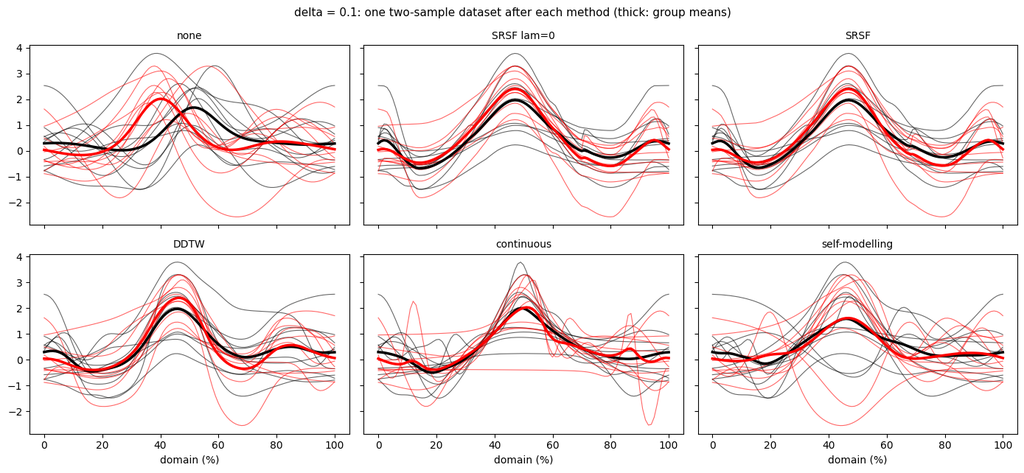

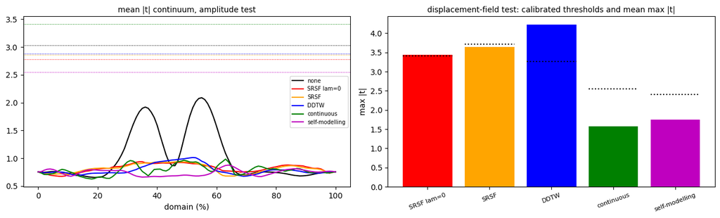

```python
c   = conds[-1]; res = results[key(c)]; J = c['J']
fig, AX = plt.subplots(2, 3, figsize=(14, 6.5), sharex=True, sharey=True)
for ax, m in zip(AX.ravel(), METHODS):
    y = res[m]['y_example']
    ax.plot(t, y[:J].T, color='k', lw=0.8, alpha=0.6); ax.plot(t, y[J:].T, color='r', lw=0.8, alpha=0.6)
    ax.plot(t, y[:J].mean(axis=0), 'k', lw=2.5); ax.plot(t, y[J:].mean(axis=0), 'r', lw=2.5)
    ax.set_title(m, size=10)
for ax in AX[1]: ax.set_xlabel('domain (%)')
plt.suptitle(f"delta = {c['delta']}: one two-sample dataset after each method (thick: group means)", size=11)
plt.tight_layout(); plt.show()
fig, AX = plt.subplots(1, 2, figsize=(13, 4))
for m in METHODS:
    AX[0].plot(t, res[m]['t'].mean(axis=0), color=COLORS[m], label=m); AX[0].axhline(zA[m], color=COLORS[m], ls=':', lw=0.8)
AX[0].set_title('mean |t| continuum, amplitude test', size=10); AX[0].set_xlabel('domain (%)'); AX[0].legend(fontsize=7)
AX[1].set_title('displacement-field test: calibrated thresholds and mean max |t|', size=10)
for k, m in enumerate(METHODS[1:]):
    AX[1].bar(k, res[m]['tdmax'].mean(), color=COLORS[m]); AX[1].plot([k-0.4, k+0.4], [zD[m]]*2, 'k:')
AX[1].set_xticks(range(len(METHODS)-1)); AX[1].set_xticklabels(METHODS[1:], rotation=20, fontsize=8); AX[1].set_ylabel('max |t|')
plt.tight_layout(); plt.show()
```

## Summary

**Simulation sizes.** Part A: N_NULL = 100 null datasets per sample size; Part B: N_ALT = 60 datasets per condition; Parts C and D: 30 datasets per condition (approximate). The numbers are printed in every results section and can be increased by re-running `make_power_notebook.py --simulate` with larger sizes (see the preamble).

**Power with random warps (Part C, approximate).** Replacing the position shift by random warps of the signal — the deformation elastic methods are designed to undo — does not change the picture at unit amplitude: unregistered power 0.43-0.77 against 0.13-0.40 for SRSF and DTW, with SRSF flat at 0.17 whatever the warp strength, and warp recovery r² below 0.2. At twice the noise SD the methods converge (0.67-0.93 against 0.93-1.00), the elastic methods keep their power as the warps strengthen while the unregistered test and the self-modelling method lose some (wsd = 0.2: DDTW 0.90, SRSF 0.70-0.80, none 0.93), and derivative DTW recovers a third of the imposed warp variance. The direction is the expected one — elastic registration pays off when the signal dominates the noise and timing variability is large — but within these ranges it never overtakes the unregistered test in a one-sample design.

**True timing differences (Part D, approximate).** In the two-sample design the roles separate as they should: registration to a pooled template removes the group timing difference from the registered amplitudes (amplitude-test power at δ = 0.1 falls from 0.30 unregistered to 0.03-0.07 after SRSF and DTW registration) and moves it into the warps, where the displacement-field test detects it with power 0.47-0.77 (SRSF 0.47-0.53, derivative DTW 0.77) against the 0.30 of the unregistered amplitude test. Continuous registration does not transfer the difference (0.03) and the self-modelling method only weakly (0.20). This is the case for registration in hypothesis testing: a *timing* effect is found by testing the warps, not the registered amplitudes, and with a null calibrated for the method. With 30 datasets per condition the numbers are indicative only.

**Implications for registration1d.** (1) A registrability check is not optional: the false-positive rate at J ≥ 10 makes an uncalibrated test after SRSF or DTW registration uninterpretable. The null distributions computed here are the reference for such a check on smooth noise; a data-driven version would compare the observed reduction with that obtained on surrogate noise of the same smoothness. (2) The default `lam='auto'` does not protect against noise alignment; a penalty strong enough to do so would have to scale with the noise, not with the signal's total variation, which argues for a penalty chosen by a null-based criterion (e.g. the smallest `lam` at which the false-positive rate on surrogate data returns to nominal). (3) The permutation tests in `notebooks/util.py` should put registration inside the permutation loop, since only that keeps α when the analysis includes registration. (4) Part D should be refined (larger N_TWO, a sweep of amplitude and of the warp variability, the self-modelling and Bayesian methods) before conclusions about which method transfers timing effects most faithfully; the amplitude-versus-timing decomposition, not one-sample detection, is where registration earns its place.